# FES 542 Lab 1

Kenneth Loonam

10/1/2021

## 1

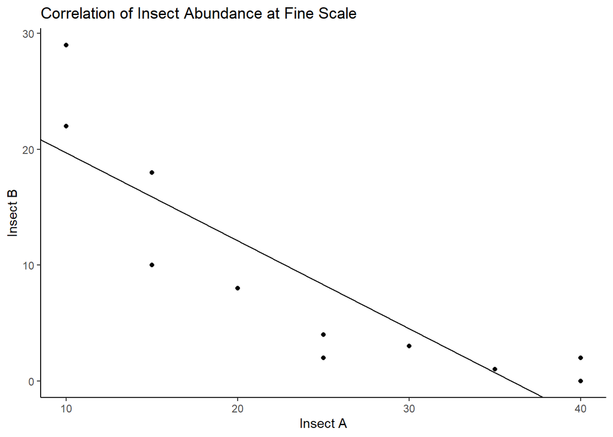

## 2

```
##
## Call:
## lm(formula = ins_b ~ ins_a)
##
## Residuals:
##     Min      1Q  Median      3Q     Max
## -6.3114 -4.2051  0.2637  2.6886  9.3260
##
## Coefficients:
##             Estimate Std. Error t value Pr(>|t|)
## (Intercept)  27.2491     3.8911   7.003  6.3e-05 ***
## ins_a        -0.7575     0.1478  -5.126 0.000623 ***
## ---
## Signif. codes:  0 '***' 0.001 '**' 0.01 '*' 0.05 '.' 0.1 ' ' 1
##
## Residual standard error: 5.206 on 9 degrees of freedom
## Multiple R-squared:  0.7448, Adjusted R-squared:  0.7165
## F-statistic: 26.27 on 1 and 9 DF,  p-value: 0.0006233
```

## 3

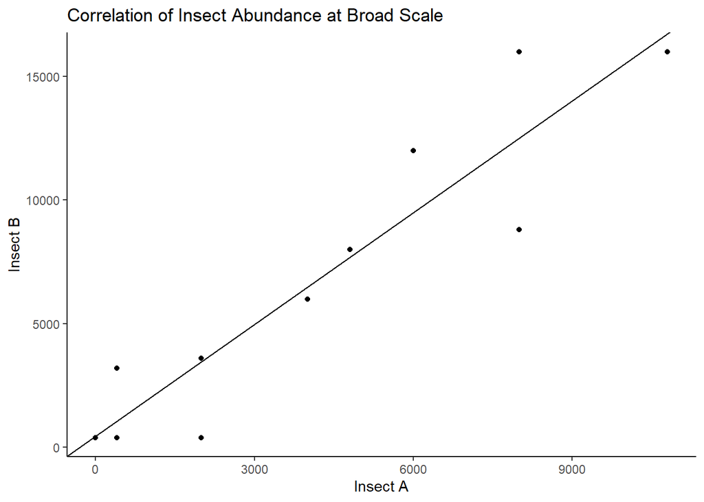

```
##
## Call:
## lm(formula = ins_b ~ ins_a)
##
## Residuals:
##     Min      1Q  Median      3Q     Max
## -3704.3  -684.3   -37.5  1240.8  3495.7
##
## Coefficients:
##              Estimate Std. Error t value Pr(>|t|)
## (Intercept)  437.4753  1091.1235   0.401    0.698
## ins_a          1.5084     0.1998   7.549 3.51e-05 ***
## ---
## Signif. codes:  0 '***' 0.001 '**' 0.01 '*' 0.05 '.' 0.1 ' ' 1
##
## Residual standard error: 2298 on 9 degrees of freedom
## Multiple R-squared:  0.8636, Adjusted R-squared:  0.8484
## F-statistic: 56.98 on 1 and 9 DF,  p-value: 3.509e-05
```

## 4

At fine scales, insects A and B are negatively correlated, however, at broad scales (e.g. larger extent and grain), insects A and B are positively correlated. The negative correlation at fine scales supports two hypotheses: that insects A and B compete or that insects A and B select for different habitats or resources at fine scales. The positive correlation at broad scales also supports multiple hypotheses. A and B could utilize similar habitats at broad scales. They could also be mutualists, which is unlikely given the fine scale observations. The observations at both scales suggest that A and B either compete but use similar habitat or that they select habitat similarly at broad scales but not at fine scales.

## 5

The mechanisms driving abundance of the two species might be different at broad and find scales (as detailed in the hypotheses in part 4). It’s also plausible that the relationships are spurious, particularly the fine scale observations. Measuring abundances in 100 sq cm plots over and extent of 100 m could be subject to extreme variance. If a similar survey were repeated along different transects, it would lead to more certainty.

## 6

The grain (0.1 to 10 sq m) and the extent (100 to 20000 m) vary between surveys.

## 7

In Starkey, the large mammals are hypothesized to have multiple relationships. Elk and mule deer could select for similar habitats or cometitively exclude each other. Similarly, coyotes could use different habitat than cougars, actively avoid cougars, or seek out cougar kills to scavenge. Understanding the scale that these behaviors happen at is critical to teasing out the relationships. If mule deer select for similar habitat as elk, there might be a lot of overlap at the home range scale. However, they could still avoid elk within their home range, leading to different results when mule deer and elk abundance are measured at different scales.